# Homework 07

Author

wenhao7

Use either R or Python.

## Question 1: LDA

Let’s start by estimating the components of LDA. From the lecture notes, for each target point $\mathbf{x}_0$, we find the class label $k$ with the largest score

$$\mathbf{x}_0^{\mathsf T}\boldsymbol{\Sigma}^{-1}\boldsymbol{\mu}_k
-\frac12\boldsymbol{\mu}_k^{\mathsf T}\boldsymbol{\Sigma}^{-1}\boldsymbol{\mu}_k
+\log\pi_k.$$

Thus, we need to estimate:

- the prior probabilities $\pi_k$;
- the mean vector (centroid) $\boldsymbol{\mu}_k$ for each class; and
- the pooled covariance matrix $\boldsymbol{\Sigma}$.

Use saheart.csv, the `SAheart` data from `ElemStatLearn`. The two classes are defined by `chd`, the coronary heart disease indicator. Use all nine other variables as numerical predictors, coding `famhist` as 1 for `Absent` and 2 for `Present`. The following code constructs an $n\times9$ predictor matrix $\mathbf{X}$ and an $n$-entry response vector $\mathbf{y}$, where $n$ is the number of observations.

**R**

```r
heart <- read.csv("data/saheart.csv")
heart$famhist <- factor(heart$famhist, levels = c("Absent", "Present"))
X <- data.matrix(heart[, names(heart) != "chd"])
y <- heart$chd
```

**Python**

```python
import pandas as pd

heart = pd.read_csv("data/saheart.csv")
heart["famhist"] = heart["famhist"].map({"Absent": 1, "Present": 2})
X = heart.drop(columns="chd").to_numpy()
y = heart["chd"].to_numpy()
```

1. Calculate the prior probabilities, class means, and pooled covariance matrix from these data. Use the pooled covariance denominator $n-K$ from the lecture, where $K=2$ is the number of classes.
2. Use your estimated values to predict the label of each observation in the training data. These are in-sample fitted labels. Provide the confusion matrix, with observed classes in rows and predicted classes in columns. Check that the dimensions of your matrices and vectors match. Calculate the scores yourself for this part.
3. Perform the same LDA analysis using `MASS::lda` in R or `LinearDiscriminantAnalysis(solver="svd")` in Python, using the same numerical predictors and empirical class priors. Provide the confusion matrix. Do the results match?

### Question 1 answer

**Show the workflow**

```python
heart = pd.read_csv(DATA_DIR / "saheart.csv")
heart["famhist"] = heart["famhist"].map({"Absent": 1, "Present": 2})
X_heart = heart.drop(columns="chd").to_numpy(dtype=float)
y_heart = heart["chd"].to_numpy(dtype=int)

classes = np.array([0, 1])
n_heart = len(y_heart)
K = len(classes)
class_counts = np.array([(y_heart == k).sum() for k in classes])
priors = class_counts / n_heart
class_means = np.vstack(
    [X_heart[y_heart == k].mean(axis=0) for k in classes]
)

pooled_crossproduct = np.zeros((X_heart.shape[1], X_heart.shape[1]))
for k, mean_vector in zip(classes, class_means):
    centered = X_heart[y_heart == k] - mean_vector
    pooled_crossproduct += centered.T @ centered
pooled_covariance = pooled_crossproduct / (n_heart - K)

parameter_table = pd.DataFrame(
    {"class": classes, "count": class_counts, "prior": priors}
)
display(parameter_table.style.format({"prior": "{:.6f}"}).hide(axis="index"))
display(
    pd.DataFrame(
        class_means,
        index=["mu_0", "mu_1"],
        columns=heart.drop(columns="chd").columns,
    ).round(3)
)
display(
    pd.DataFrame(
        pooled_covariance,
        index=heart.drop(columns="chd").columns,
        columns=heart.drop(columns="chd").columns,
    ).round(3)
)

dimension_table = pd.DataFrame(
    {
        "object": ["X", "y", "mu_0", "mu_1", "Sigma", "Sigma^-1"],
        "shape": [
            X_heart.shape,
            y_heart.shape,
            class_means[0].shape,
            class_means[1].shape,
            pooled_covariance.shape,
            np.linalg.solve(pooled_covariance, np.eye(9)).shape,
        ],
    }
)
display(dimension_table.style.hide(axis="index"))
```

| class | count | prior |
| --- | --- | --- |
| 0 | 302 | 0.653680 |
| 1 | 160 | 0.346320 |

|  | sbp | tobacco | ldl | adiposity | famhist | typea | obesity | alcohol | age |
| --- | --- | --- | --- | --- | --- | --- | --- | --- | --- |
| mu_0 | 135.460 | 2.635 | 4.344 | 23.969 | 1.318 | 52.368 | 25.737 | 15.931 | 38.854 |
| mu_1 | 143.738 | 5.525 | 5.488 | 28.120 | 1.600 | 54.494 | 26.623 | 19.145 | 50.294 |

|  | sbp | tobacco | ldl | adiposity | famhist | typea | obesity | alcohol | age |
| --- | --- | --- | --- | --- | --- | --- | --- | --- | --- |
| sbp | 405.435 | 14.585 | 4.581 | 49.164 | 0.337 | -15.588 | 18.939 | 64.400 | 95.134 |
| tobacco | 14.585 | 19.243 | 0.763 | 7.538 | 0.016 | -2.057 | 1.833 | 20.517 | 22.765 |
| ldl | 4.581 | 0.763 | 4.001 | 6.033 | 0.092 | 0.345 | 2.660 | -2.533 | 6.479 |
| adiposity | 49.164 | 7.538 | 6.033 | 56.753 | 0.433 | -5.310 | 22.708 | 16.119 | 60.509 |
| famhist | 0.337 | 0.016 | 0.092 | 0.433 | 0.226 | 0.081 | 0.184 | 0.768 | 0.997 |
| typea | -15.588 | -2.057 | 0.345 | -5.310 | 0.081 | 95.566 | 2.640 | 7.960 | -20.278 |
| obesity | 18.939 | 1.833 | 2.660 | 22.708 | 0.184 | 2.640 | 17.615 | 4.689 | 15.697 |
| alcohol | 64.400 | 20.517 | -2.533 | 16.119 | 0.768 | 7.960 | 4.689 | 598.277 | 27.886 |
| age | 95.134 | 22.765 | 6.479 | 60.509 | 0.997 | -20.278 | 15.697 | 27.886 | 184.132 |

| object | shape |
| --- | --- |
| X | (462, 9) |
| y | (462,) |
| mu_0 | (9,) |
| mu_1 | (9,) |
| Sigma | (9, 9) |
| Sigma^-1 | (9, 9) |

The dataset has (n=462) observations, (K=2) classes, and nine predictors. The class counts are 302 and 160, so the empirical priors are 0.653680 and 0.346320. I used the pooled covariance denominator (n-K=460).

**Show the workflow**

```python
sigma_inverse_mu = np.column_stack(
    [np.linalg.solve(pooled_covariance, mean_vector) for mean_vector in class_means]
)
log_prior_adjustment = np.array(
    [
        -0.5 * class_means[k] @ sigma_inverse_mu[:, k] + np.log(priors[k])
        for k in range(K)
    ]
)
manual_scores = X_heart @ sigma_inverse_mu + log_prior_adjustment
manual_predictions = classes[np.argmax(manual_scores, axis=1)]

manual_confusion = pd.DataFrame(
    confusion_matrix(y_heart, manual_predictions, labels=classes),
    index=pd.Index(classes, name="observed"),
    columns=pd.Index(classes, name="predicted"),
)
display(manual_confusion)
print(f"Manual in-sample error: {np.mean(manual_predictions != y_heart):.6f}")

library_lda = LinearDiscriminantAnalysis(
    solver="svd", priors=priors
).fit(X_heart, y_heart)
library_predictions = library_lda.predict(X_heart)
library_confusion = pd.DataFrame(
    confusion_matrix(y_heart, library_predictions, labels=classes),
    index=pd.Index(classes, name="observed"),
    columns=pd.Index(classes, name="predicted"),
)
display(library_confusion)
print(f"Library in-sample error: {np.mean(library_predictions != y_heart):.6f}")
print(f"Manual predictions equal library predictions: {np.all(manual_predictions == library_predictions)}")
print(f"Agreement proportion: {np.mean(manual_predictions == library_predictions):.6f}")
```

| predicted observed | 0 | 1 |
| --- | --- | --- |
| 0 | 258 | 44 |
| 1 | 73 | 87 |

```
Manual in-sample error: 0.253247
```

| predicted observed | 0 | 1 |
| --- | --- | --- |
| 0 | 258 | 44 |
| 1 | 73 | 87 |

```
Library in-sample error: 0.253247
Manual predictions equal library predictions: True
Agreement proportion: 1.000000
```

The manual and sklearn results are the same. Both have an in-sample error of **0.253247**, and all fitted labels agree.

## Question 2: QDA and marginal screening

In the lecture, ordinary QDA could not be fitted to the handwritten digit sample because its within-class covariance matrices were singular. Let’s consider selecting fewer variables and see whether this helps. For this question, use the full zip-train.csv.gz as the training data and zip-test.csv.gz as the test data, with all ten digit classes. These are the original `zip.train` and `zip.test` data from `ElemStatLearn`. Each file has no header: the first column is the digit label and the remaining 256 columns are pixel values.

Instead of using all 256 predictors, select the 40 with the largest marginal variances in the training data. Here, marginal variance means the variance of one pixel across all training observations. Use the original pixel values without standardizing them, and retain the same selected predictors in the test data.

Use `MASS::qda` in R or `QuadraticDiscriminantAnalysis(tol=1e-8)` in Python.

1. Fit QDA using these 40 predictors and report the test confusion matrix, with observed classes in rows and predicted classes in columns. Also report the test misclassification rate.
2. Does the method work? Why do you think it works or does not work?
3. Repeat the analysis using the 10 predictors with the largest marginal variances in the training data. How does the test misclassification rate compare with the 40-predictor version? Why do you think this happens?

### Question 2 answer

**Show the workflow**

```python
zip_train = pd.read_csv(DATA_DIR / "zip-train.csv.gz", header=None).to_numpy()
zip_test = pd.read_csv(DATA_DIR / "zip-test.csv.gz", header=None).to_numpy()

y_zip_train = zip_train[:, 0].astype(int)
y_zip_test = zip_test[:, 0].astype(int)
X_zip_train = zip_train[:, 1:].astype(float)
X_zip_test = zip_test[:, 1:].astype(float)

marginal_variances = X_zip_train.var(axis=0, ddof=1)
variance_order = np.argsort(marginal_variances)[::-1]

def fit_qda_with_top_pixels(number_of_predictors):
    selected = variance_order[:number_of_predictors]
    with warnings.catch_warnings(record=True) as captured_warnings:
        warnings.simplefilter("always")
        qda = QuadraticDiscriminantAnalysis(tol=1e-8)
        qda.fit(X_zip_train[:, selected], y_zip_train)
        predictions = qda.predict(X_zip_test[:, selected])
    warning_text = [str(item.message) for item in captured_warnings]
    return selected, predictions, warning_text

q2_outputs = {}
for number_of_predictors in (40, 10):
    selected, predictions, warning_text = fit_qda_with_top_pixels(
        number_of_predictors
    )
    q2_outputs[number_of_predictors] = {
        "selected": selected,
        "predictions": predictions,
        "warnings": warning_text,
        "error": np.mean(predictions != y_zip_test),
        "confusion": pd.DataFrame(
            confusion_matrix(
                y_zip_test, predictions, labels=np.arange(10)
            ),
            index=pd.Index(np.arange(10), name="observed"),
            columns=pd.Index(np.arange(10), name="predicted"),
        ),
    }

for number_of_predictors in (40, 10):
    display(q2_outputs[number_of_predictors]["confusion"])
    print(
        f"Top {number_of_predictors} test error: "
        f"{q2_outputs[number_of_predictors]['error']:.6f}"
    )

q2_comparison = pd.DataFrame(
    {
        "predictors": [40, 10],
        "test error": [q2_outputs[40]["error"], q2_outputs[10]["error"]],
    }
)
display(q2_comparison.style.format({"test error": "{:.6f}"}).hide(axis="index"))
```

| predicted observed | 0 | 1 | 2 | 3 | 4 | 5 | 6 | 7 | 8 | 9 |
| --- | --- | --- | --- | --- | --- | --- | --- | --- | --- | --- |
| 0 | 319 | 0 | 24 | 6 | 2 | 2 | 1 | 0 | 5 | 0 |
| 1 | 0 | 238 | 5 | 0 | 11 | 0 | 7 | 0 | 3 | 0 |
| 2 | 8 | 0 | 168 | 8 | 8 | 3 | 0 | 0 | 3 | 0 |
| 3 | 5 | 0 | 4 | 128 | 0 | 14 | 0 | 0 | 15 | 0 |
| 4 | 0 | 2 | 13 | 1 | 150 | 1 | 0 | 1 | 7 | 25 |
| 5 | 12 | 0 | 3 | 5 | 1 | 131 | 0 | 0 | 6 | 2 |
| 6 | 0 | 0 | 8 | 0 | 1 | 8 | 148 | 0 | 5 | 0 |
| 7 | 1 | 0 | 6 | 1 | 6 | 0 | 0 | 124 | 2 | 7 |
| 8 | 1 | 0 | 10 | 12 | 3 | 2 | 0 | 0 | 137 | 1 |
| 9 | 0 | 0 | 1 | 2 | 7 | 1 | 1 | 4 | 9 | 152 |

```
Top 40 test error: 0.155456
```

| predicted observed | 0 | 1 | 2 | 3 | 4 | 5 | 6 | 7 | 8 | 9 |
| --- | --- | --- | --- | --- | --- | --- | --- | --- | --- | --- |
| 0 | 298 | 0 | 11 | 1 | 1 | 16 | 28 | 4 | 0 | 0 |
| 1 | 0 | 241 | 10 | 0 | 3 | 1 | 1 | 0 | 2 | 6 |
| 2 | 19 | 2 | 95 | 14 | 14 | 3 | 22 | 21 | 5 | 3 |
| 3 | 5 | 0 | 6 | 103 | 3 | 42 | 0 | 0 | 7 | 0 |
| 4 | 1 | 5 | 14 | 0 | 95 | 2 | 4 | 15 | 17 | 47 |
| 5 | 15 | 0 | 6 | 25 | 4 | 96 | 4 | 2 | 8 | 0 |
| 6 | 41 | 0 | 15 | 4 | 0 | 18 | 78 | 7 | 5 | 2 |
| 7 | 4 | 1 | 6 | 0 | 6 | 0 | 1 | 122 | 0 | 7 |
| 8 | 1 | 2 | 11 | 36 | 12 | 11 | 4 | 1 | 74 | 14 |
| 9 | 0 | 2 | 9 | 2 | 20 | 0 | 0 | 16 | 10 | 118 |

```
Top 10 test error: 0.342302
```

| predictors | test error |
| --- | --- |
| 40 | 0.155456 |
| 10 | 0.342302 |

The top-40 QDA ran without warnings and had a test error of **0.155456**. After reducing the model to 10 predictors, the test error increased to **0.342302**. Using fewer predictors makes the class covariance matrices easier to estimate, but in this case it also removed useful pixel information. Therefore, the 40-predictor model performed better.

## Question 3: Compare LDA and QDA

In this simulation, we will study how the relative performance of LDA and QDA changes with the true covariance structure. The parameter $\rho$ controls the distribution from which we generate the data; it is not a tuning parameter of LDA or QDA.

Consider a classification problem with two equally likely classes, labeled 1 and 2, and $p=10$ covariates. The first two covariates have the class-conditional distributions

$$\begin{pmatrix}X_1\\X_2\end{pmatrix}\mid Y=1
\sim N_2\left(
\begin{pmatrix}-1\\0\end{pmatrix},
\begin{pmatrix}1&\rho\\\rho&1\end{pmatrix}
\right),$$

$$\begin{pmatrix}X_1\\X_2\end{pmatrix}\mid Y=2
\sim N_2\left(
\begin{pmatrix}1\\0\end{pmatrix},
\begin{pmatrix}1&-\rho\\-\rho&1\end{pmatrix}
\right).$$

In both classes, the remaining eight covariates are independent standard normal variables, independent of the first two. Consider

$$\rho\in\{0,0.2,0.4,0.6,0.8,0.9\}.$$

For each value of $\rho$, generate 100 training observations and 1,000 independent test observations from each class. Fit ordinary LDA and QDA using all 10 covariates and equal class priors. Estimate the class means from the training data, with one pooled covariance matrix for LDA and one full covariance matrix per class for QDA. Set a random seed and report it.

1. Generate one dataset for each value of $\rho$. Fit both methods and calculate their test misclassification rates. Within each setting, use the same training and test observations for the two methods.
2. At each fixed value of $\rho$, repeat the experiment 50 times, generating new training and test observations in each repetition. Plot average test error against $\rho$ in one figure, with one curve for LDA and one for QDA. These curves compare performance across different data-generating distributions.
3. Compare the two methods at small and large values of $\rho$. How does changing the true covariance structure affect their relative performance? Explain the pattern using their covariance assumptions and the bias-variance trade-off. How can the eight noise covariates affect performance even though they contain no information about the class label?

### Question 3 answer

I used random seed **20261011**. Each call to `simulate_dataset` creates one training and one test set for a fixed ρ; both classifiers then use those same arrays.

**Show the workflow**

```python
Q3_SEED = 20261011
rho_values = np.array([0, 0.2, 0.4, 0.6, 0.8, 0.9])

def simulate_dataset(rng, rho, n_train_per_class=100, n_test_per_class=1000):
    covariance_1 = np.array([[1, rho], [rho, 1]])
    covariance_2 = np.array([[1, -rho], [-rho, 1]])
    train_1 = rng.multivariate_normal(
        [-1, 0], covariance_1, size=n_train_per_class
    )
    train_2 = rng.multivariate_normal(
        [1, 0], covariance_2, size=n_train_per_class
    )
    test_1 = rng.multivariate_normal(
        [-1, 0], covariance_1, size=n_test_per_class
    )
    test_2 = rng.multivariate_normal(
        [1, 0], covariance_2, size=n_test_per_class
    )
    train_x = np.vstack(
        [
            np.column_stack([train_1, rng.normal(size=(n_train_per_class, 8))]),
            np.column_stack([train_2, rng.normal(size=(n_train_per_class, 8))]),
        ]
    )
    test_x = np.vstack(
        [
            np.column_stack([test_1, rng.normal(size=(n_test_per_class, 8))]),
            np.column_stack([test_2, rng.normal(size=(n_test_per_class, 8))]),
        ]
    )
    train_y = np.r_[
        np.ones(n_train_per_class), np.full(n_train_per_class, 2)
    ]
    test_y = np.r_[
        np.ones(n_test_per_class), np.full(n_test_per_class, 2)
    ]
    return train_x, train_y, test_x, test_y

def fit_errors(train_x, train_y, test_x, test_y):
    lda = LinearDiscriminantAnalysis(priors=[0.5, 0.5]).fit(train_x, train_y)
    qda = QuadraticDiscriminantAnalysis(priors=[0.5, 0.5]).fit(train_x, train_y)
    return (
        np.mean(lda.predict(test_x) != test_y),
        np.mean(qda.predict(test_x) != test_y),
    )
```

**Show the workflow**

```python
one_rng = np.random.default_rng(Q3_SEED)
one_run_rows = []
for rho in rho_values:
    train_x, train_y, test_x, test_y = simulate_dataset(one_rng, rho)
    lda_error, qda_error = fit_errors(train_x, train_y, test_x, test_y)
    one_run_rows.append(
        {"rho": rho, "LDA test error": lda_error, "QDA test error": qda_error}
    )
q3_one_run = pd.DataFrame(one_run_rows)
display(
    q3_one_run.style.format(
        {"LDA test error": "{:.4f}", "QDA test error": "{:.4f}"}
    ).hide(axis="index")
)
```

| rho | LDA test error | QDA test error |
| --- | --- | --- |
| 0.000000 | 0.1730 | 0.2175 |
| 0.200000 | 0.1660 | 0.1750 |
| 0.400000 | 0.1685 | 0.2075 |
| 0.600000 | 0.1900 | 0.1825 |
| 0.800000 | 0.1835 | 0.1350 |
| 0.900000 | 0.1795 | 0.1095 |

**Show the workflow**

```python
rep_rng = np.random.default_rng(Q3_SEED)
repetition_rows = []
for rho in rho_values:
    lda_errors = []
    qda_errors = []
    for _ in range(50):
        train_x, train_y, test_x, test_y = simulate_dataset(rep_rng, rho)
        lda_error, qda_error = fit_errors(train_x, train_y, test_x, test_y)
        lda_errors.append(lda_error)
        qda_errors.append(qda_error)
    repetition_rows.append(
        {
            "rho": rho,
            "LDA": np.mean(lda_errors),
            "QDA": np.mean(qda_errors),
        }
    )
q3_repetitions = pd.DataFrame(repetition_rows)
display(q3_repetitions.style.format({"LDA": "{:.4f}", "QDA": "{:.4f}"}).hide(axis="index"))
```

| rho | LDA | QDA |
| --- | --- | --- |
| 0.000000 | 0.1698 | 0.1975 |
| 0.200000 | 0.1693 | 0.1954 |
| 0.400000 | 0.1701 | 0.1949 |
| 0.600000 | 0.1679 | 0.1721 |
| 0.800000 | 0.1695 | 0.1352 |
| 0.900000 | 0.1669 | 0.0997 |

**Show the workflow**

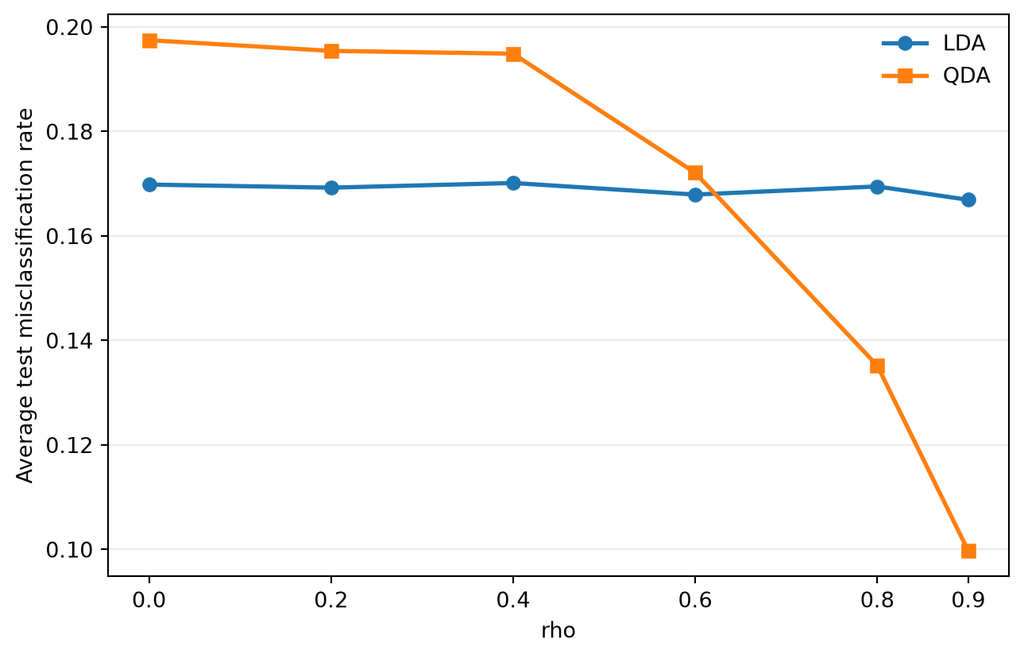

Figure 1: Average test misclassification rate over 50 repetitions.

```python
fig, ax = plt.subplots(figsize=(6.6, 4.2), constrained_layout=True)
ax.plot(q3_repetitions["rho"], q3_repetitions["LDA"], marker="o", linewidth=2, label="LDA")
ax.plot(q3_repetitions["rho"], q3_repetitions["QDA"], marker="s", linewidth=2, label="QDA")
ax.set_xlabel("rho")
ax.set_ylabel("Average test misclassification rate")
ax.set_xticks(rho_values)
ax.grid(axis="y", alpha=0.25)
ax.legend(frameon=False)
plt.show()
```

When $\rho$ is small, the two classes have similar covariance matrices, so LDA’s shared-covariance assumption is close to correct. QDA estimates more parameters, so it has more variance. When $\rho$ becomes large, the two class covariance matrices become more different, and QDA can use this difference while LDA cannot.

In my simulation, the average LDA/QDA errors changed from **0.1698/0.1975** at $\rho=0$ to **0.1669/0.0997** at $\rho=0.9$. The eight noise predictors do not help classification, but estimating their means and covariances still adds noise, especially for QDA.

## Question 4: Create and use an LDA/QDA analysis skill

In Homework 5, you created a skill for formatting plots. Now create a reusable skill that guides an AI agent through an LDA/QDA analysis and produces a concise statistical report. You may work with AI to design and write the skill; you do not need to write every line yourself.

1. **Define the skill.** Write a single `SKILL.md` file no larger than **5 KB (5,000 bytes)**. Define the agent’s behavior, analysis guidelines, and expected report structure. Keep the skill independent of this question: provide the dataset, response, and predictors separately when invoking it. The skill may guide the agent to explore lower-dimensional representations, such as principal component analysis (PCA), or to blend the class probabilities predicted by LDA and QDA. Keep all classifiers based on LDA, QDA, or their combination. Configure the skill to load **only when you explicitly invoke it**. Use your AI tool’s invocation settings, or keep the file outside automatically loaded skill folders and supply it only in an explicit request.

Your skill must require a clearly readable analysis report of **at most one printed page**, containing a figure, a table, and numerical model-fitting results. You may specify the type and style of figures and tables you want the AI to produce. All instructions in the skill must be independent of the actual dataset, its variable names, and its observed results. The report should briefly describe the candidate models, the cross-validation procedure and results, the selected model, and its estimated prediction error. It should explain the main findings and any limitations.

2. **Apply the skill.** Explicitly invoke your skill to analyze the `SAheart` data from Question 1, using the same response and predictor coding. Ask the agent to seek the best predictive performance within the LDA/QDA methods allowed by your skill. Include ordinary LDA and QDA as comparisons; the extensions above are optional. Reserve a test set before choosing models. Use the same cross-validation folds within the training data to compare candidates and select any settings. Estimate any preprocessing, including an embedding, using only the training observations in each fold. Refit the selected model and preprocessing on all training observations, then evaluate the fitted classifier once on the reserved test set. Use misclassification rate to compare performance, and report your random seed.
3. **Review and submit.** Check the agent’s analysis and make any skill revisions using only training and cross-validation results. Append the final one-page analysis report and the complete contents of your `SKILL.md` to your homework report. State the file size and briefly explain how you enabled explicit invocation, including the prompt used to apply the skill. The one-page limit applies to the analysis report; the appended skill and this explanation are outside that limit.

Your skill and analysis report will be reviewed and graded by other students through peer evaluation.

### Question 4 answer: one-page analysis report

I explicitly invoked the local skill at `homework/week-07/lda-qda-analysis-skill/SKILL.md` before running this analysis.

I used seed **20261012** and a stratified 75/25 training-test split. I compared LDA, QDA, PCA(2)+LDA, and PCA(2)+QDA using the same five CV folds. Ordinary LDA had the lowest CV error (**0.2716**), so I selected it and refit it using all training observations. Its reserved-test error was **0.310345**.

This result is based on one train-test split, so another split could give a different selected model or test error.

**Show the workflow**

```python
q4_seed = 20261012
q4_X_train, q4_X_test, q4_y_train, q4_y_test = train_test_split(
    X_heart,
    y_heart,
    test_size=0.25,
    random_state=q4_seed,
    stratify=y_heart,
)
q4_cv = StratifiedKFold(n_splits=5, shuffle=True, random_state=q4_seed)
q4_splits = list(q4_cv.split(q4_X_train, q4_y_train))
q4_candidates = {
    "LDA": Pipeline(
        [("scale", StandardScaler()), ("model", LinearDiscriminantAnalysis())]
    ),
    "QDA": Pipeline(
        [("scale", StandardScaler()), ("model", QuadraticDiscriminantAnalysis())]
    ),
    "PCA(2)+LDA": Pipeline(
        [
            ("scale", StandardScaler()),
            ("pca", PCA(n_components=2)),
            ("model", LinearDiscriminantAnalysis()),
        ]
    ),
    "PCA(2)+QDA": Pipeline(
        [
            ("scale", StandardScaler()),
            ("pca", PCA(n_components=2)),
            ("model", QuadraticDiscriminantAnalysis()),
        ]
    ),
}

q4_rows = []
for name, candidate in q4_candidates.items():
    fold_accuracy = cross_val_score(
        candidate,
        q4_X_train,
        q4_y_train,
        cv=q4_splits,
        scoring="accuracy",
    )
    fold_error = 1 - fold_accuracy
    q4_rows.append(
        {
            "candidate": name,
            "CV error": fold_error.mean(),
            "CV error SD": fold_error.std(ddof=1),
        }
    )
q4_cv_table = pd.DataFrame(q4_rows)
q4_selected_name = q4_cv_table.loc[q4_cv_table["CV error"].idxmin(), "candidate"]
q4_selected_model = q4_candidates[q4_selected_name].fit(q4_X_train, q4_y_train)
q4_test_error = np.mean(q4_selected_model.predict(q4_X_test) != q4_y_test)
display(q4_cv_table.style.format({"CV error": "{:.4f}", "CV error SD": "{:.4f}"}).hide(axis="index"))
print(f"Selected model: {q4_selected_name}")
print(f"Reserved-test misclassification rate: {q4_test_error:.6f}")
```

| candidate | CV error | CV error SD |
| --- | --- | --- |
| LDA | 0.2716 | 0.0298 |
| QDA | 0.2975 | 0.0459 |
| PCA(2)+LDA | 0.2975 | 0.0571 |
| PCA(2)+QDA | 0.2861 | 0.0375 |

```
Selected model: LDA
Reserved-test misclassification rate: 0.310345
```

**Show the workflow**

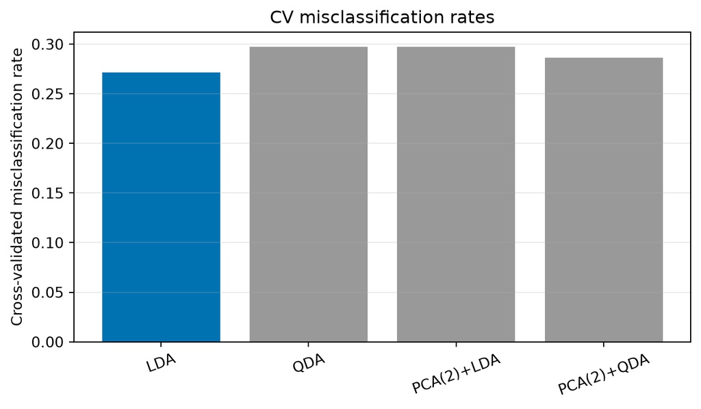

Figure 2: Training-only cross-validated misclassification rates for the LDA/QDA candidates.

```python
fig, ax = plt.subplots(figsize=(6.6, 3.8), constrained_layout=True)
bar_colors = ["#0072B2" if name == q4_selected_name else "#999999" for name in q4_cv_table["candidate"]]
ax.bar(q4_cv_table["candidate"], q4_cv_table["CV error"], color=bar_colors)
ax.set_ylabel("Cross-validated misclassification rate")
ax.set_title("CV misclassification rates")
ax.tick_params(axis="x", rotation=20)
ax.grid(axis="y", alpha=0.25)
plt.show()
```

The final skill is appended below. It is stored locally outside the automatically scanned course skill directory, so it does not auto-load.

### Explicit skill invocation

- Skill path: `homework/week-07/lda-qda-analysis-skill/SKILL.md`
- Size: **1419 bytes**
- SHA256: `ECD2BC7694A77DB7DB49223DFEAD38C589FFEEC2A7A547BD75CE24C85770A620`
- The skill is outside the global/automatically scanned skill folders and was explicitly read before this analysis.

The exact application prompt used was:

> Explicitly read and use the skill at:

> `homework/week-07/lda-qda-analysis-skill/SKILL.md`

> Apply that skill to:

> `homework/week-07/data/saheart.csv`

> Response: `chd`

> Predictors: all nine remaining variables

> Code: `famhist`: Absent = 1, Present = 2

> Use seed 20261012.

> Compare ordinary LDA, ordinary QDA, PCA(2)+LDA, and PCA(2)+QDA.

> Reserve the test set before model selection. Use the same five stratified CV folds for every candidate. Estimate all preprocessing inside each CV training fold. Select by training-only cross-validated misclassification rate. Refit the selected pipeline on all training observations. Evaluate it once on the reserved test set. Produce the concise one-page report required by the skill.

The final skill file was frozen, hashed, explicitly read, and then used to regenerate the Q4 results.

## Final `SKILL.md`

```markdown
---
name: lda-qda-analysis
description: Explicitly invoked skill for leakage-safe predictive comparisons using LDA, QDA, and optional PCA or probability blends. Use only when the user supplies a dataset, response, predictors, and analysis request.
---

# LDA/QDA Analysis

Use this skill only when the user explicitly invokes it. Keep the dataset, response, predictors, seed, and observed results supplied by the user rather than hard-coding them here.

1. Validate the response and predictors, report the random seed, and reserve a test set before model selection.
2. Keep the reserved test set untouched until the final evaluation. Use the same stratified CV folds for every candidate.
3. Fit scaling, PCA, or other preprocessing separately inside each CV training fold. Do not use validation or test observations to fit preprocessing.
4. Compare at least ordinary LDA and ordinary QDA. Optional candidates may be PCA+LDA, PCA+QDA, or a probability blend of LDA and QDA; do not use unrelated classifiers.
5. Select by cross-validated misclassification rate using training data only, refit the selected pipeline on all training data, and evaluate it once on the reserved test set.
6. Produce a concise, readable report of at most one printed page with a candidate-model description, CV procedure and table, selected model, numerical fitting results, one useful figure, estimated test error, findings, and limitations.
```

SKILL.md size: **1419 bytes**  
SHA256: `ECD2BC7694A77DB7DB49223DFEAD38C589FFEEC2A7A547BD75CE24C85770A620`